# Course project Writeup

Roger Rafanell

18 de agosto de 2015

## Loading cleaning and pre-processing data

Load the training dataset **pml-training.csv**:

```r
library(caret)
```

```r
library(ggplot2)

set.seed(32343)
setwd("/home/roger/Escritorio/predmachlearn/project/")
data <- read.csv('data/pml-training.csv', header=TRUE, sep=",")
```

After loading the training dataset, the first thing was inspect the dataset looking for *NA* values. The columns containing *NAs* have been removed:

```r
#Remove columns with NA
data <- data[sapply(data, function(x) !any(is.na(x)))]
```

We have also discarded the columns that not explains the model so much, the ones with a near zero variance, as well as the ones contaning factors which are not directly related to the numerical input data collected by the sensors:

```r
# get indices of data.frame columns with low variance
badCols <- nearZeroVar(data)

# remove those "bad" columns from the data set
data <- data[, -badCols]
data$cvtd_timestamp <- NULL
data$user_name <- NULL
```

The filtered dataset has been splitted in a training (75%) and testing (25%) subsets:

```r
inTrain <- createDataPartition(y = data$classe, p=0.75, list=FALSE)
training <- data[inTrain, ]
testing <- data[-inTrain, ]
```

In some cases, there is a need to use Principal Component Analysis (PCA) to transform the data to a smaller sub–space where the new variable are uncorrelated with one another. We performed this pre-processing technique in order to capture the features containing the 80% of the variance.

The *preProcess* method applies (in one call) Box-Cox transformation to correct for skewness, center and to scale each variable.

```r
# Pre-processing: Box-Cox transformation, centered, scaled and principal component signal extraction
preProc <- preProcess(training[, -57], method=c("BoxCox", "center", "scale", "pca"), thresh= 0.80)
trainPC <- predict(preProc, training[, -57])
preProc
```

```
##
## Call:
## preProcess.default(x = training[, -57], method = c("BoxCox",
##  "center", "scale", "pca"), thresh = 0.8)
##
## Created from 14718 samples and 56 variables
## Pre-processing: Box-Cox transformation, centered, scaled,
##  principal component signal extraction
##
## Lambda estimates for Box-Cox transformation:
##    Min. 1st Qu.  Median    Mean 3rd Qu.    Max.    NA's
##   0.700   0.700   0.800   1.167   1.725   2.000      50
##
## PCA needed 15 components to capture 80 percent of the variance
```

Note the PCA needed **15 components** to capture the desired variance theshold.

## Data Inspection

This could be understood as the *big picture*, and could be used to detect some interesting patterns hidden in the data.

The following operations highlight some of the most clustered regions:

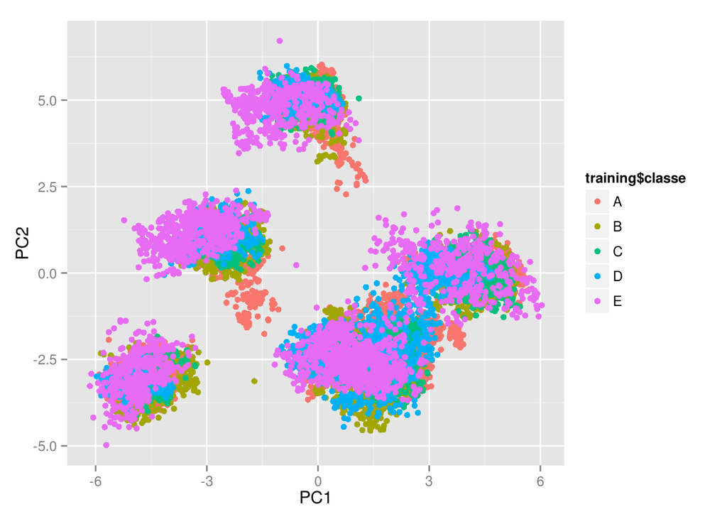

```r
# Plotting some of the relevant principal component interactions
qplot(PC1, PC2, data=trainPC, col=training$classe, xlab="PC1", ylab="PC2")
```

## Fitting the model

Since we have found some interesting patterns, is time to train a **random forest** model. This is one of the most commonly used classification algorithm as well as the **boosting** family. The model has been resampled with 10-fold cross-validation and saved as an object to speed-up the load operations.

```r
# Fit the model with 10-fold cross validation
## check if model exists? If not, refit:
if(file.exists("model/modelRF.rda")) {
    ## load model
    load(file = "model/modelRF.rda")
} else {
    ## (re)fit the model and save it
    train_control <- trainControl(method="cv", number=10)
    modelFit <- train(training$classe ~ ., method="rf", data=trainPC, trControl=train_control, prox=TRUE)
    save(modelFit, file = "model/modelRF.rda")
}
```

```r
modelFit
```

```
## Random Forest
##
## 14718 samples
##    14 predictors
##     5 classes: 'A', 'B', 'C', 'D', 'E'
##
## No pre-processing
## Resampling: Cross-Validated (10 fold)
## Summary of sample sizes: 13247, 13246, 13247, 13246, 13246, 13246, ...
## Resampling results across tuning parameters:
##
##   mtry  Accuracy   Kappa      Accuracy SD  Kappa SD
##    2    0.9750648  0.9684656  0.002457691  0.003108687
##    8    0.9675231  0.9589280  0.003179436  0.004022101
##   15    0.9557680  0.9440594  0.005242169  0.006637370
##
## Accuracy was used to select the optimal model using  the largest value.
## The final value used for the model was mtry = 2.
```

```r
pred <- predict(modelFit, trainPC)
confusionMatrix(pred, training$classe)
```

```
## Confusion Matrix and Statistics
##
##           Reference
## Prediction    A    B    C    D    E
##          A 4185    0    0    0    0
##          B    0 2848    0    0    0
##          C    0    0 2567    0    0
##          D    0    0    0 2412    0
##          E    0    0    0    0 2706
##
## Overall Statistics
##
##                Accuracy : 1
##                  95% CI : (0.9997, 1)
##     No Information Rate : 0.2843
##     P-Value [Acc > NIR] : < 2.2e-16
##
##                   Kappa : 1
##  Mcnemar's Test P-Value : NA
##
## Statistics by Class:
##
##                      Class: A Class: B Class: C Class: D Class: E
## Sensitivity            1.0000   1.0000   1.0000   1.0000   1.0000
## Specificity            1.0000   1.0000   1.0000   1.0000   1.0000
## Pos Pred Value         1.0000   1.0000   1.0000   1.0000   1.0000
## Neg Pred Value         1.0000   1.0000   1.0000   1.0000   1.0000
## Prevalence             0.2843   0.1935   0.1744   0.1639   0.1839
## Detection Rate         0.2843   0.1935   0.1744   0.1639   0.1839
## Detection Prevalence   0.2843   0.1935   0.1744   0.1639   0.1839
## Balanced Accuracy      1.0000   1.0000   1.0000   1.0000   1.0000
```

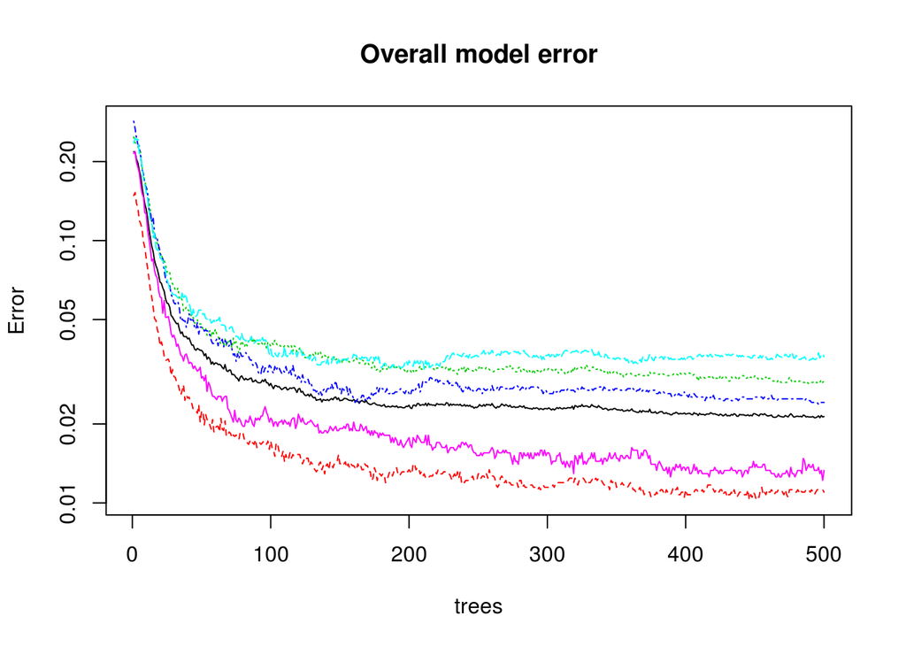

```r
plot(main="Overall model error", modelFit$finalModel, log="y")
```

## Testing the model

The model has been tested using a dedicated test. As it could be appreciated, the model predictions are not perfect but they are so close, reaching an *out-of-sample accuracy* of **0.977**.

```r
# Apply the same PCA transformation to the testing set
testPC <- predict(preProc, testing[, -57])
```

```r
# Testing the predictor with the testing set
pred <- predict(modelFit, testPC)
confusionMatrix(testing$classe, pred)
```

```
## Confusion Matrix and Statistics
##
##           Reference
## Prediction    A    B    C    D    E
##          A 1384    1    6    3    1
##          B   14  917   17    0    1
##          C    4   13  825   10    3
##          D    1    2   24  775    2
##          E    0    3    3    5  890
##
## Overall Statistics
##
##                Accuracy : 0.977
##                  95% CI : (0.9724, 0.981)
##     No Information Rate : 0.2861
##     P-Value [Acc > NIR] : < 2.2e-16
##
##                   Kappa : 0.9708
##  Mcnemar's Test P-Value : 0.006963
##
## Statistics by Class:
##
##                      Class: A Class: B Class: C Class: D Class: E
## Sensitivity            0.9865   0.9797   0.9429   0.9773   0.9922
## Specificity            0.9969   0.9919   0.9926   0.9929   0.9973
## Pos Pred Value         0.9921   0.9663   0.9649   0.9639   0.9878
## Neg Pred Value         0.9946   0.9952   0.9877   0.9956   0.9983
## Prevalence             0.2861   0.1909   0.1784   0.1617   0.1829
## Detection Rate         0.2822   0.1870   0.1682   0.1580   0.1815
## Detection Prevalence   0.2845   0.1935   0.1743   0.1639   0.1837
## Balanced Accuracy      0.9917   0.9858   0.9677   0.9851   0.9947
```

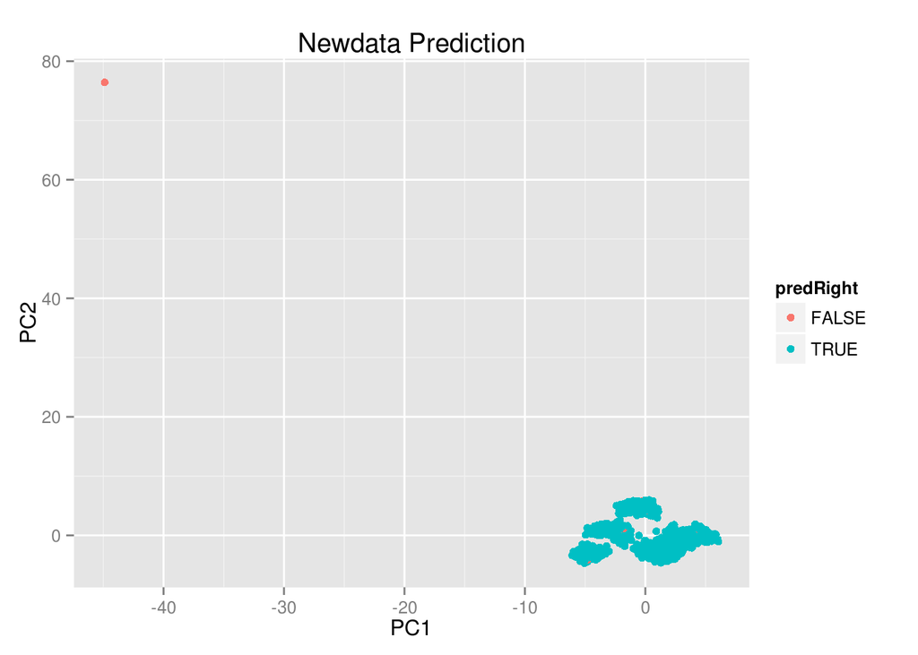

```r
# Plotting correct and incorrect predictions
testPC$predRight <- pred==testing$classe
qplot(PC1, PC2, colour=predRight, data=testPC, main="Newdata Prediction")
```

## Validation

Finally, the model has been validated against the data provided in the **pml-testing.csv** file:

```r
# Testing with validation data (20 samples)
validation <- read.csv('data/pml-testing.csv', header=TRUE, sep=",")

# Remove columns with NAs
validation <- validation[sapply(data, function(x) !any(is.na(x)))]

# get indices of data.frame columns with low variance
badCols <- nearZeroVar(validation)

# remove those "bad" columns from the validation set
validation <- validation[, -badCols]
validation$cvtd_timestamp <- NULL
validation$user_name <- NULL
validationPC <- predict(preProc, validation[, -57])
results <- predict(modelFit, validationPC)
```

Predicting the following results:

```r
results
```

```
##  [1] B A A A A E A B A A A A B A B E A B B B
## Levels: A B C D E
```